# **Influences on Medmo Booking Rates**

### Name: Zoe Birnbaum

### Link to Github Pages: https://zbirnbaum.github.io/

A note for professor and TAs: refer to your email for a notebook containing more information about the data set.

```python
import pandas as pd
import numpy as np
import matplotlib.pyplot as plt
```

Read in data set from excel file:

```python
df = pd.read_excel('dataset_proj.xlsx')
```

## Project Goals

The goal of this project is to determine what factors influence booking rates at Medmo Inc., a healthcare in tech company. Medmo facilitates radiology appointments for their clients, both B2B and B2C. Every scan request that comes in through their online portal contains a multitude of information that could be helpful in drawing correlations and creating prediction models. I, Zoe Birnbaum, will be analyzing their data set of all appointment requests to discover correlations between variables to identify what influences the likelihood that a requested appointment is booked, and if we can predict that based on such variables.

## The Data Set

This data includes all requested appointments from the company's portal from April 2018 through April 2024. Attached to each request is information regarding geographic location of the patient, type of scan/appointment, B2B vs. B2C, stage of request (scheduled, completed, closed, etc.), date and time of request (and booking, if applicable), and more. I chose to work with this data set because of my experience working with the company and personal interest in the healthcare in tech field. The set provides a sufficient amount of data, information, and variables to allow me to follow my goal for this project.

**Research Questions**

Questions I hope to answer with this data:

1. What factors are correlated with successful bookings? Based on those factors, can we predict whether a request will be booked?:
   - Geographic location of the patient/appointment request
   - Type of scan
   - Number of previous cancellations (if any)
   - Complexity of the request (additional tasks, etc.)
2. Is the complexity of a request correlated with the time taken to book appointment after request?

RQ1 will look at all requests, and RQ2 will look at only requests that are scheduled and beyond (only those requests have additional data on booking, such as time taken). In the section for cleaning up data, I will create a second DataFrame for these RQs (df1 and df2 respectively).

**Why this data set is correct for answering the above**

The data set contains variables for all factors included in my branched-off research questions. I have over 80k scan requests to work with, which will yield valid statistics.

**Hypotheses:**

1. The following factors can predict a successful appointment request:
   - The location for the requested appointment is New York
   - The type of scan is an Ultrasound
   - Request is of low complexity (minimal additional tasks, etc. -- see 'Request Complexity' section)
   - 0 previous appointment cancelations
2. The complexity of a request and the time taken to book the appointment -- from the time the appointment was requested -- are positively correlated.

# Cleaning up the data

Since each observation is identified by the request ID, I'll make `TestRequestID` the index:

```python
df.set_index("TestRequestID", inplace = True)
```

I'll drop the `Latitude`, `Longitude`, and `ZipCode` columns, and just use the data set's column `State` for location purposes.

```python
df = df.drop(columns=['Latitude', 'Longitude', 'ZipCode'])
```

The column `HasReportFile` is currently represented as Boolean (1 and 0), but would be more readable with values "Yes" and "No" instead.

```python
df['HasReportFile'] = df['HasReportFile'].map({
    0: "No",
    1: "Yes"
})
```

Since I'll be looking at the time between `DateRequested` and `DateBooked`, I'm going to create a new column in the DataFrame called `BookingTime` that represents this difference:

```python
df["BookingTime"] = df["DateBooked"] - df["DateRequested"]
```

An important metric in analyzing this data is the complexity of a scan request. Additional tasks and comments on a scan request, such as needing to ask a physician for a script, increase the complexity and I hypothesize that this a) reduces the likelihood that a request will become scheduled, and b) increases BookingTime. Let's create an algorithm to calculate complexity of a scan request:

```python
def calculate_request_complexity(dfRow):
  score = 0
  # The weight of complexity for each task/comment was provided to me by the company:
  score += (dfRow['ExternalTasks'] * 10)
  score += (dfRow['InternalTasks'] * 5)
  score += (dfRow['B2BComments'] * 2)
  score += (dfRow['InternalComments'] * 2)
  score += (dfRow['ICComments'] * 1)
  return score
```

I'll add a `Complexity` column to the DataFrame so I can use this measure in the future:

```python
df['Complexity']=df.apply(calculate_request_complexity, axis=1)
```

Dropping `StatusID` as it's redundant to `HasReportFile`, and I will stick with the boolean value in this data set. Also, dropping other "Booking" variables, as the new column `BookingTime` is what I'll be using:

```python
df = df.drop(columns=['StatusID', 'FirstBooking', 'LastBooking', 'DateRequested', 'DateBooked'])
```

Time to handle the NaNs/missing data. These are the columns that contain such values and how many:

```python
print(df.isnull().any())
```

```
StageID               False
StageName             False
Modality              False
ChannelSource         False
AppointmentDate        True
State                  True
Cancelations          False
InternalTasks         False
ExternalTasks         False
PriorAuthStatus       False
TimeToOrderEntry       True
TimeToA1Completion     True
InternalComments      False
B2BComments           False
ICComments            False
HasReportFile         False
BookingTime            True
Complexity            False
dtype: bool
```

```python
print("AppointmentDate: ", len(df[df['AppointmentDate'].isnull() == True]))
print("State: ", len(df[df['State'].isnull() == True]))
print("TimeToOrderEntry: ", len(df[df['TimeToOrderEntry'].isnull() == True]))
print("TimeToA1Completion: ", len(df[df['TimeToA1Completion'].isnull() == True]))
print("BookingTime: ", len(df[df['BookingTime'].isnull() == True]))
```

```
AppointmentDate:  35840
State:  595
TimeToOrderEntry:  27951
TimeToA1Completion:  70925
BookingTime:  35838
```

`BookingTime` and `AppointmentDate` only contain data for requests that are scheduled and beyond, which is why there are so many null values. We are not looking at either variable for RQ1, so I will not include those columns in df1, and double check that when df2 is created, this problem is solved.

`TimeToA1Completion` and `TimeToOrderEntry` contain too many NaNs, and I am not looking at either variable in either RQ, so I will drop those columns as well.

`State`, however, is very relevant to RQ1 so I will drop the rows that are missing that data. The amount of observations dropped is negligible in relation to the total amount of observations (80k+), unlike the other 4 NaN-heavy variables, which is why I am taking this approach with `State`.

```python
df = df.drop(columns=['TimeToA1Completion', 'TimeToOrderEntry'])
```

```python
df = df.dropna(subset=['State'])
```

Time to create df1 and df2. Recall, df1 is for RQ1, which is looking at all requests (many of which have not been booked), and df2 is for RQ2, which is looking at only requests that have been scheduled and/or completed. In other words, df2 is a subset of df1, with the addition of "booking" variables that would have been null in df1.

```python
df1 = df.drop(columns=['AppointmentDate', 'BookingTime'])
```

```python
df2 = df[df['StageID'] >= 4]
# StageID of 4 = scheduled, StageID of 5 = completed
```

Let's double check both DataFrames for null values:

```python
print(df1.isnull().any())
print(df2.isnull().any())
```

```
StageID             False
StageName           False
Modality            False
ChannelSource       False
State               False
Cancelations        False
InternalTasks       False
ExternalTasks       False
PriorAuthStatus     False
InternalComments    False
B2BComments         False
ICComments          False
HasReportFile       False
Complexity          False
dtype: bool
StageID             False
StageName           False
Modality            False
ChannelSource       False
AppointmentDate      True
State               False
Cancelations        False
InternalTasks       False
ExternalTasks       False
PriorAuthStatus     False
InternalComments    False
B2BComments         False
ICComments          False
HasReportFile       False
BookingTime          True
Complexity          False
dtype: bool
```

```python
print("AppointmentDate: ", len(df2[df2['AppointmentDate'].isnull() == True]))
print("BookingTime: ", len(df2[df2['BookingTime'].isnull() == True]))
```

```
AppointmentDate:  3
BookingTime:  1
```

Again, out of 80,000+ observations, these amounts are negligible so they can be dropped.

```python
df2 = df2.dropna(subset=['BookingTime', 'AppointmentDate'])
```

```python
print(df2.isnull().any())
```

```
StageID             False
StageName           False
Modality            False
ChannelSource       False
AppointmentDate     False
State               False
Cancelations        False
InternalTasks       False
ExternalTasks       False
PriorAuthStatus     False
InternalComments    False
B2BComments         False
ICComments          False
HasReportFile       False
BookingTime         False
Complexity          False
dtype: bool
```

Perfect! The data is ready to work with.

# Preliminary Data Workings

## The `State` variable:

Since I am interested in the relationship between successful bookings and geographic location, I'll start by taking a look at data related to requests by state:

```python
df1[["State"]].describe()
```

|  | State |
| --- | --- |
| count | 85326 |
| unique | 50 |
| top | NY |
| freq | 53913 |

New York leads the states in the total amount of requests at 53,913, which is 63.18% of all requests:

```python
percent = (df1['State'].value_counts()["NY"]) / (len(df1))
print(f"{percent:.2%}")
```

```
63.18%
```

Next, I'll generate a graph showing the percentage distribution of requests by state:

```python
state_counts = df1['State'].value_counts()
state_percentages = state_counts / (len(df1)) * 100
```

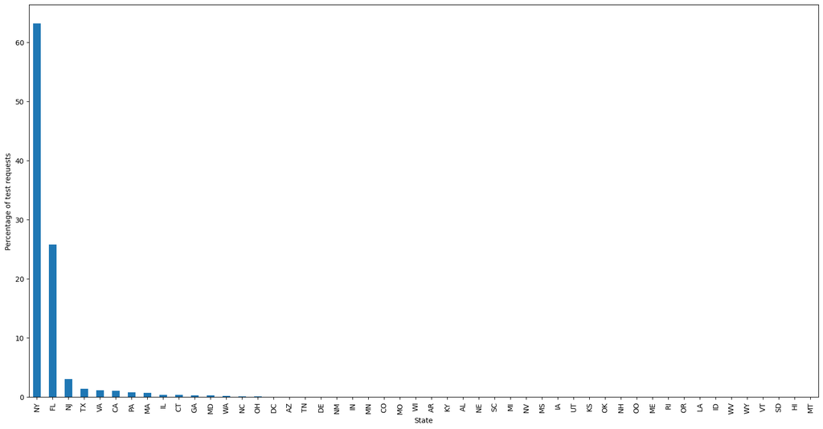

```python
state_percentages.plot.bar(figsize=(20, 10), ylabel='Percentage of test requests', xlabel='State')
```

The leading states are: New York, Florida, and New Jersey. The following table shows the relationship between StageID and State where State = (NJ | NY | FL), via a joint & marginal distribution table:

```python
top_states = df[(df['State'] == 'NJ') | (df['State'] == 'NY') | (df['State'] == 'FL')]
pd.crosstab(df.StageID, top_states.State, normalize=True, margins=True)
```

| State StageID | FL | NJ | NY | All |
| --- | --- | --- | --- | --- |
| 0 | 0.114878 | 0.019356 | 0.268086 | 0.402320 |
| 4 | 0.003031 | 0.000076 | 0.025163 | 0.028271 |
| 5 | 0.162505 | 0.013600 | 0.393304 | 0.569409 |
| All | 0.280413 | 0.033033 | 0.686554 | 1.000000 |

## "Successful" Requests

Throughout this report I will refer to requests as "successful", so let's define and find out some information about that. A successful request is a scan that is at the scheduling stage or beyond: it is scheduled or completed. What's the percentage of scan requests that fall into this category?

```python
df_scheduled_completed = df1[(df1["StageName"] == "Scheduled") | (df1["StageName"] == "Completed")]
print(f"{(len(df_scheduled_completed) / len(df1)):.2%}")
```

```
58.59%
```

The "best-case scenario" for a scan request is one that is not only scheduled/completed, but has a report file attached. Let's see what percent of requests are at the best-case level:

```python
best_case = df_scheduled_completed[df_scheduled_completed["HasReportFile"] == "Yes"]
print(f"{(len(best_case) / len(df1)):.2%}")
```

```
35.63%
```

## The `Modality` variable:

Next, let's look at the concentrations of scan types. Amount of successful scan requests per type of scan (`modality` variable):

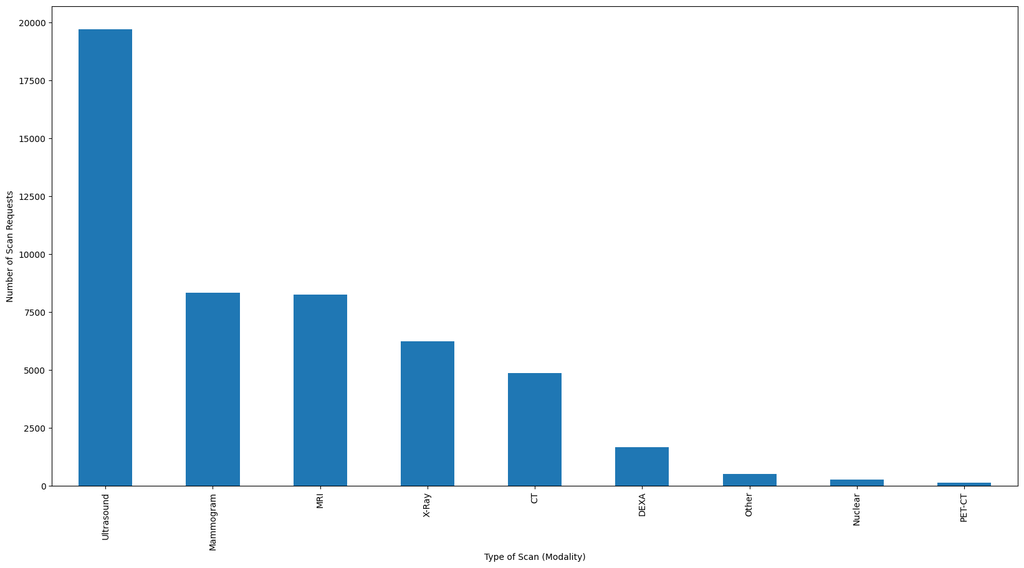

```python
counts = df_scheduled_completed['Modality'].value_counts()
counts.plot.bar(figsize=(20, 10), ylabel='Number of Scan Requests', xlabel='Type of Scan (Modality)')
```

```python
percent_ultrasound_success = len(df_scheduled_completed[df_scheduled_completed["Modality"] == "Ultrasound"])/len(df_scheduled_completed)
print(f"{percent_ultrasound_success:.2%}")
```

```
39.44%
```

```python
percent_all_ultrasounds = len(df1[df1["Modality"] == "Ultrasound"])/len(df1)
print(f"{percent_all_ultrasounds:.2%}")
```

```
35.47%
```

Ultrasounds make up a bit more than a third of all scan requests. There isn't much difference in the percent of Ultrasounds between the "all scans" group and the "successful" group.

## Cancelations

Another variable of interest in this project is `Cancelations`, which represents the amount of times the order was canceled (if any). I hypothesized that zero previous cancelations influence successful bookings, but let's see how many cancelations are at each level of `StageID`:

```python
dfx = df[['StageID', 'Cancelations']]
dfx.groupby('StageID').sum()
```

| StageID | Cancelations |
| --- | --- |
| 0 | 16995 |
| 4 | 636 |
| 5 | 8008 |

The amount of cancelations in successful bookings is lower than un-successful.

## Request Complexity

As mentioned before, I added `Complexity` to the DataFrame(s). Let's take a closer look into that variable, and how it is related to other variables of interest:

```python
df['Complexity'].describe()
```

```
count    85326.000000
mean        32.751471
std         34.935679
min          2.000000
25%         12.000000
50%         22.000000
75%         40.000000
max        596.000000
Name: Complexity, dtype: float64
```

The scatter plot below visualizes the relationship between Complexity, Cancelations, and StageID, where all variables are standardized to be on the same scale:

```python
df_std = df[['Complexity', 'Cancelations', 'StageID']]
df_std = ((df_std - df_std.mean())/df_std.std())
```

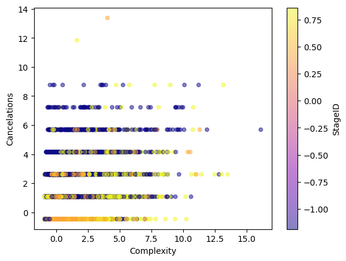

```python
df_std.plot.scatter(x="Complexity", y="Cancelations", c="StageID",
                     cmap="plasma", alpha=.5);
```

We can see that the amount of successful requests are highly concentrated in the lower complexity and zero cancelations region. This is promising in proving my first hypothesis, however model creation and evaluation is still necessary.

To compute more-than-simple mathematic calculations on `BookingTime`, I will convert these values from TimeDelta objects into floats, where the unit is days:

```python
df2["BookingTimeInts"] = (df2["BookingTime"].dt.days +
 (df2["BookingTime"].dt.components["hours"]/24) +   # 24 hours per day
 (df2["BookingTime"].dt.components["minutes"]/1440) +   # 1440 minutes per day
 (df2["BookingTime"].dt.components["seconds"]))   # 86400 seconds per day
```

This next scatter plot shows the relationship between complexity and time taken to book, also standardized to be on the same scale:

```python
df2_std = df2[['Complexity', 'BookingTimeInts']]
df2_std = ((df2_std - df2_std.mean())/df2_std.std())
```

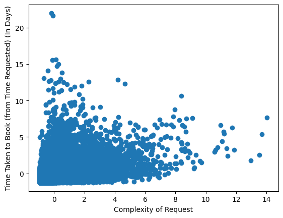

```python
plt.scatter(df2_std["Complexity"], df2_std["BookingTimeInts"])

plt.xlabel("Complexity of Request")
plt.ylabel("Time Taken to Book (from Time Requested) (In Days)")

plt.show()
```

# Models Overview:

1. I will use the state, modality, cancellations, and complexity score (IVs) to predict whether an appointment will be booked (DV). I will use a K-Nearest-Neighbors Classifier, as this DV is categorical.
2. I will use the complexity score to predict the time between when the request is made and appointment is booked. I will use a K-Nearest-Neighbors Regressor, as this DV is continuous.

# RQ1: will a request become successful?

As mentioned above, I am going to implement a simple 5-Nearest-Neighbors classifier to predict the `StageID` of a scan request:

```python
from sklearn.neighbors import KNeighborsClassifier
from sklearn.preprocessing import StandardScaler
from sklearn.pipeline import Pipeline
from sklearn.model_selection import cross_val_score
from sklearn.feature_extraction import DictVectorizer
```

```python
# Define the training data and represent features as a list of dictionaries
features = ["State", "Modality", "Cancelations", "Complexity"]
x_train_dict = df1[features].to_dict(orient="records")
y_train = df1["StageID"]
```

```python
# dummy encoding:
vec = DictVectorizer(sparse=False)
vec.fit(x_train_dict)
x_train = vec.transform(x_train_dict)

# scale the features:
scaler = StandardScaler()
scaler.fit(x_train)
x_train_std = scaler.transform(x_train)
```

```python
# Fit the 5-nearest neighbors model:
model = KNeighborsClassifier(n_neighbors=5)
model.fit(x_train_std, y_train)
y_train_pred = model.predict(x_train_std)
y_train_pred
```

```
array([0, 0, 0, ..., 0, 5, 5])
```

What will the model predict for a request that models the first hypothesis?:

```python
x_new_dict = [{
    "State": "NY",
    "Modality": "Ultrasound",
    "Cancelations": 0,
    "Complexity": 5   # recall 50th percentile of Complexity is ~22
}]
x_new = vec.transform(x_new_dict)
x_new_std = scaler.transform(x_new)

print(model.predict(x_new_std))
model.predict_proba(x_new_std)
```

```
[0]
```

```
array([[0.6, 0. , 0.4]])
```

With a 5-nearest-neighbors model, the prediction is that such a request is of `StageID == 0` (which corresponds to `StageName == Closed`) with a 60% probability. I will evaluate accuracy at each k and choose the k with the highest accuracy to use for the model:

```python
def get_accuracy(k):
    model = KNeighborsClassifier(n_neighbors=k)
    pipeline = Pipeline([
    ("scaler", scaler),
    ("model", model)
])
    accuracy= cross_val_score(pipeline, x_train, y_train,cv=10, scoring="accuracy").mean()
    return accuracy
```

```
1     0.551650
2     0.551755
4     0.596981
3     0.599513
5     0.618253
10    0.619143
11    0.620632
6     0.621300
7     0.622882
8     0.624136
12    0.624488
13    0.628168
15    0.628261
9     0.628706
23    0.629621
```

[output cut: 16 more lines]

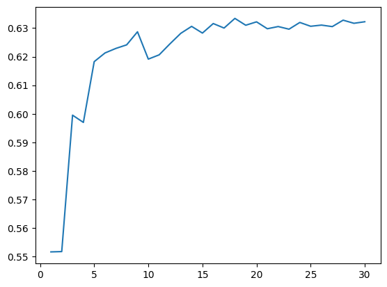

```python
ks = pd.Series(range(1, 31))
ks.index = range(1, 31)
accuracies = ks.apply(get_accuracy)

accuracies.plot.line()
accuracies.sort_values()
```

k=18 optimizes accuracy:

```python
# Fit the 18-nearest neighbors model:
model = KNeighborsClassifier(n_neighbors=18)
model.fit(x_train_std, y_train)

# Use the model to predict on the same test point
print(model.predict(x_new_std))
model.predict_proba(x_new_std)
```

```
[0]
```

```
array([[0.83333333, 0.        , 0.16666667]])
```

With the value of k to optimize precision, the prediction is the same, but with a higher probability. I subjectively chose the value of 5 for "low complexity" on the new test point, so I will now use the model to predict if a request with `Complexity` == (0, 12, and 20) will yield the same result. I chose these numbers because they are other ways to define "low" based on the values of `Complexity`:

```python
x_new_dict_0 = [{
    "State": "NY",
    "Modality": "Ultrasound",
    "Cancelations": 0,
    "Complexity": 0
}]
x_new_0 = vec.transform(x_new_dict_0)
x_new_0_std = scaler.transform(x_new_0)

print(model.predict(x_new_0_std))
model.predict_proba(x_new_0_std)
```

```
[0]
```

```
array([[0.61111111, 0.        , 0.38888889]])
```

```python
x_new_dict_12 = [{
    "State": "NY",
    "Modality": "Ultrasound",
    "Cancelations": 0,
    "Complexity": 12
}]
x_new_12 = vec.transform(x_new_dict_12)
x_new_12_std = scaler.transform(x_new_12)

print(model.predict(x_new_12_std))
model.predict_proba(x_new_12_std)
```

```
[5]
```

```
array([[0.38888889, 0.        , 0.61111111]])
```

```python
x_new_dict_20 = [{
    "State": "NY",
    "Modality": "Ultrasound",
    "Cancelations": 0,
    "Complexity": 20
}]
x_new_20 = vec.transform(x_new_dict_20)
x_new_20_std = scaler.transform(x_new_20)

print(model.predict(x_new_20_std))
model.predict_proba(x_new_20_std)
```

```
[5]
```

```
array([[0., 0., 1.]])
```

If we combine and average the probabilities of these low complexity requests being at stage `Closed` or `Completed`...

```python
prob_0 = (0.833 + 0.611 + 0.389 + 0) / 4
prob_5 = (0.167 + 0.389 + 0.611 + 1) / 4

print(prob_0, prob_5)
```

```
0.45825 0.54175
```

We can see that it is more likely that a low complexity will be `Completed` rather than `Closed`. Below, I will compute the both the precision and recall of this model, where precision is the proportion of successful scan requests that are true positives, whereas recall is the proportion of successful scan requests that are positives, as opposed to negatives:

```python
pipeline = Pipeline([
    ("scaler", scaler),
    ("model", model)
])
```

```python
# Precision:
cross_val_score(pipeline, x_train, (y_train >=4),
                cv=10, scoring="precision").mean()
```

```
0.7173601228151975
```

```python
# Recall:
cross_val_score(pipeline, x_train, (y_train >=4),
                cv=10, scoring="recall").mean()
```

```
0.6962038847769554
```

In conclusion, scan requests in which the location of the requested appointment is New York, the type of scan is an Ultrasound, there haven't been any previous cancelations, and complexity is low (below 50th percentile of all `Complexity` scores), are likely to become successful with a ~54% probability. This is supported by the model's not-the-highest (but balanced) precision and recall.

# RQ2: is there a correlation between complexity and time taken to book?

As mentioned above, I am going to implement a K-Nearest-Neighbors Regressor to predict `BookingTime` based on `Complexity`

```python
def get_kNN_pred(x_new, n):
    """Given new observation, returns n nearest neighbors prediction
    """
    dists = np.sqrt(((x_train - x_new)**2).sum(axis=1))
    inds_sorted = dists.sort_values().index[:(n)]
    return y_train.loc[inds_sorted].mean()

x_train = df2[["Complexity"]]
y_train = df2["BookingTimeInts"]

x_new = pd.DataFrame()
x_new["Complexity"] = np.arange(0, 600, 5)
```

The graph below shows the scatterplot of Complexity and BookingTime from the DataFrame, overlayed with the Regression model line for k=100:

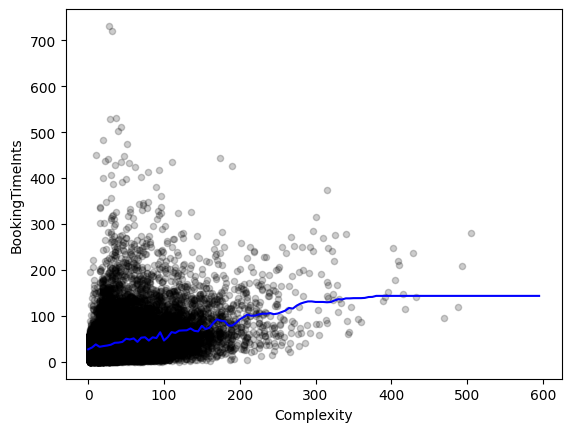

```python
y_pred_100 = x_new.apply(get_kNN_pred, axis=1, args=(100,))

# Predictive model for k=30 nearest neighbors:
y_pred_100.index = x_new["Complexity"]
df2.plot.scatter(x="Complexity", y="BookingTimeInts", color="black", alpha=.2)
y_pred_100.plot.line(color="blue")
```

`Complexity` and `BookingTime` are positively correlated, supporting my second hypothesis. Next, I will evaluate the strength of this correlation:

```python
index_array = np.array(y_pred_100.index)
values_array = np.array(y_pred_100.values)
```

```python
np.corrcoef(index_array, values_array)[0, 1]
```

```
0.9343630142678436
```

Based off of this regression model, `BookingTime` and `Complexity`'s correlation is positive and very strong! To evaluate the performance of this model, I'll compute the cross-validation error at different levels of k:

```
100    20.999402
99     21.022531
98     21.037882
97     21.054166
96     21.069855
         ...
5      33.259823
4      34.549659
3      35.233311
2      36.569867
1      38.069530
Length: 100, dtype: float64
```

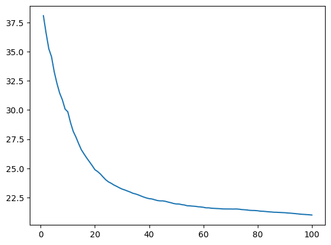

```python
from sklearn.neighbors import KNeighborsRegressor

x_dict = df2[["Complexity"]].to_dict(orient="records")
y = df2["BookingTimeInts"]

def get_cv_error(k):
    model = KNeighborsRegressor(n_neighbors=k)
    pipeline = Pipeline([("vectorizer", vec), ("scaler", scaler), ("fit", model)])
    mae = np.mean(-cross_val_score(
        pipeline, x_dict, y,
        cv=10, scoring="neg_mean_absolute_error"
    ))
    return mae

ks = pd.Series(range(1, 101))
ks.index = range(1, 101)
test_errs = ks.apply(get_cv_error)

test_errs.plot.line()
test_errs.sort_values()
```

From this graph, we can see that the (cross-validation) test error decreases as k increases, and starts to plateau around k=100, where error = ~21. I predict it will continue to plateau as k increases, but let's double check with a very large value of k:

```python
k = pd.Series(range(30000, 30001))
k.index = range(30000, 30001)
test_err = k.apply(get_cv_error)
```

```python
print(test_err)
```

```
30000    19.721953
dtype: float64
```

The larger a value of k, the lower the test error will be, until k reaches about 100 and the test error will plateau.

# Conclusion

**Findings**

1. The bulk of all scan requests are from New York and are for Ultrasounds.
2. Cancelations are more present in un-successful scan requests than successful ones.
3. The following values were able to predict a successful scan request
   - The appointment request's location is New York
   - The type of scan is an Ultrasound
   - 0 previous cancelations of this order
   - Low (score <= 20) complexity

   However, the precision (0.717) and recall (0.696) of this classification model, along with the probability of the above statement (54%), indicate that future work may need to be completed to create a better model for this prediction.
4. The complexity of a scan request and the time taken to book the appointment are strongly and positively correlated (r=0.934)

**Limitations**

As displayed in some of the graphs and tables in this report, there was no representation for `StageID` values 1-3 in this data set (respectively: Requested, Qualified, Imaging Center Assigned). Even though the `StageID` variables were primarily registered in this report as successful or un-successful, the lack of representation of these values leads to a non-representative sample.